# APM1110-FA9

Nathalie Faith Ricafort

2026-11-27

# Introduction

This assessment explores stochastic independence, sums of independent random variables, and conditional distributions using R. Simulated data will be used to demonstrate the relationships between random variables and compare theoretical results with simulated results.

# Dataset Description or Simulation Design

This assessment uses simulated data instead of an external dataset. Random variables are generated using probability distributions available in R. A fixed random seed is used to make the results reproducible.

# Part 1: Stochastic Independence

## 1.1 Description of the Random Variables

Two continuous random variables, X and Y, are generated using a bivariate normal model.

The variables are constructed as follows:

- X follows a standard normal distribution.
- Y is generated using X and an independent standard normal random variable.
- The correlation between X and Y is set to 0.70.

Since the correlation is not zero, the variables are dependent.

```r
rho <- 0.70

Z1 <- rnorm(n)
Z2 <- rnorm(n)

X1 <- Z1
Y1 <- rho * Z1 + sqrt(1 - rho^2) * Z2

correlation <- cor(X1, Y1)

correlation
```

```
## [1] 0.6948977
```

## 1.2 Numerical and Graphical Relationship

The sample correlation measures the strength and direction of the linear relationship between X and Y.

```r
cat("Correlation between X and Y:", round(correlation, 4))
```

```
## Correlation between X and Y: 0.6949
```

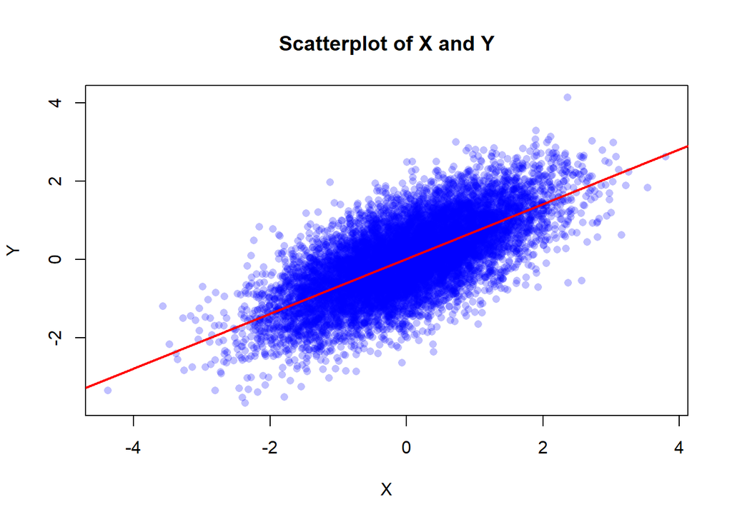

```r
plot(
  X1, Y1,
  main = "Scatterplot of X and Y",
  xlab = "X",
  ylab = "Y",
  pch = 16,
  col = rgb(0, 0, 1, 0.25)
)

abline(lm(Y1 ~ X1), lwd = 2, col = "red")
```

The scatterplot shows a positive linear relationship between X and Y. As X increases, Y tends to increase as well.

## 1.3 Marginal Distributions

The marginal distributions describe X and Y separately.

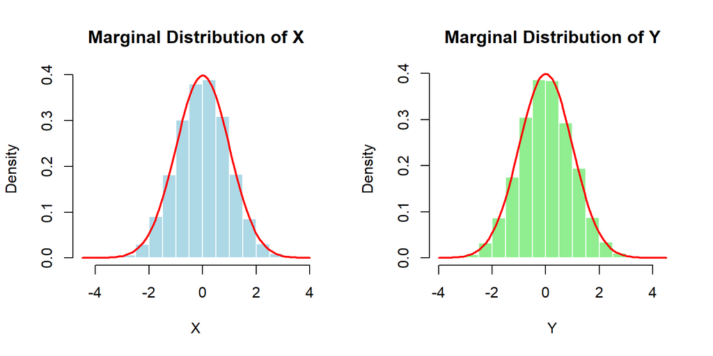

```r
par(mfrow = c(1, 2))

hist(
  X1,
  probability = TRUE,
  main = "Marginal Distribution of X",
  xlab = "X",
  col = "lightblue",
  border = "white"
)

curve(dnorm(x), add = TRUE, col = "red", lwd = 2)

hist(
  Y1,
  probability = TRUE,
  main = "Marginal Distribution of Y",
  xlab = "Y",
  col = "lightgreen",
  border = "white"
)

curve(dnorm(x), add = TRUE, col = "red", lwd = 2)
```

```r
par(mfrow = c(1, 1))
```

Both variables have approximately standard normal marginal distributions.

## 1.4 Joint Distribution

The joint distribution describes the behavior of X and Y together.

```r
smoothScatter(
  X1, Y1,
  main = "Joint Distribution of X and Y",
  xlab = "X",
  ylab = "Y"
)
```

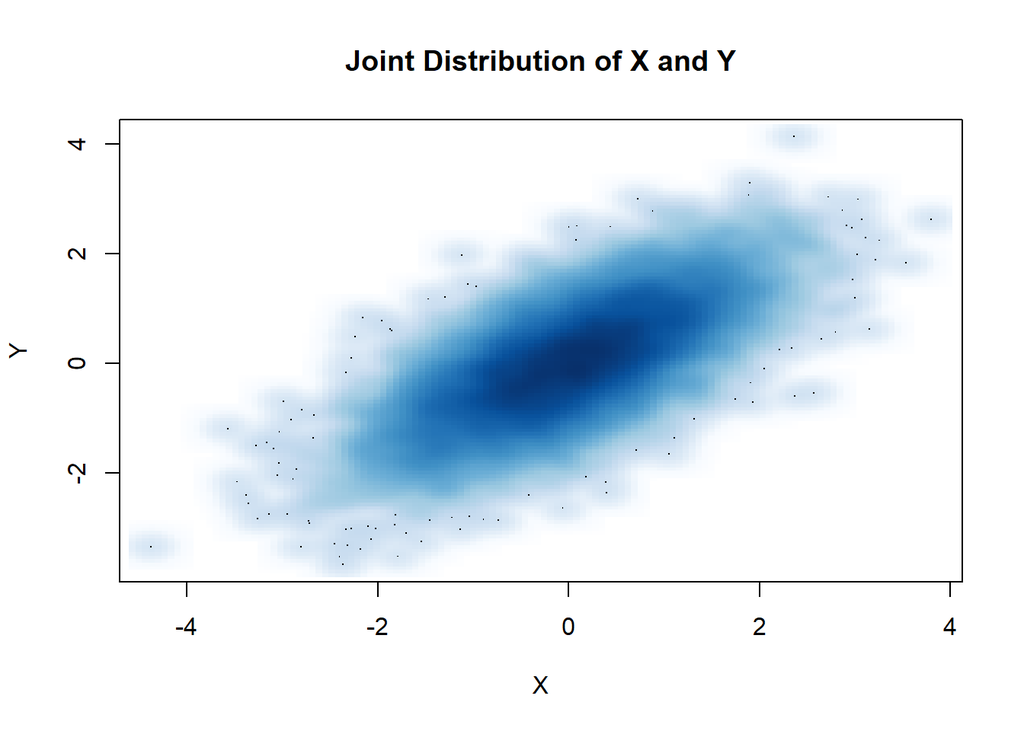

The joint distribution shows that the observations tend to follow an upward pattern, indicating a positive relationship.

## 1.5 Factorization Criterion

Two random variables are independent if their joint probability density can be expressed as the product of their marginal probability densities.

For continuous random variables:

fX,Y(x, y) = fX(x) * fY(y)

The following code compares empirical joint probabilities with the products of empirical marginal probabilities.

```r
# Create finite breakpoints based on the observed data
breaks_X <- seq(
  min(X1) - 0.001,
  max(X1) + 0.001,
  length.out = 6
)

breaks_Y <- seq(
  min(Y1) - 0.001,
  max(Y1) + 0.001,
  length.out = 6
)

# Divide X and Y into intervals
bin_X <- cut(X1, breaks = breaks_X, include.lowest = TRUE)
bin_Y <- cut(Y1, breaks = breaks_Y, include.lowest = TRUE)

# Calculate empirical joint probabilities
joint_table <- prop.table(table(bin_X, bin_Y))

# Calculate empirical marginal probabilities
marginal_X <- prop.table(table(bin_X))
marginal_Y <- prop.table(table(bin_Y))

# Calculate products of marginal probabilities
independent_table <- outer(
  as.numeric(marginal_X),
  as.numeric(marginal_Y)
)

# Compare the probabilities
comparison <- data.frame(
  Joint_Probability = as.vector(joint_table),
  Product_of_Marginals = as.vector(independent_table)
)

head(comparison, 10)
```

```
##    Joint_Probability Product_of_Marginals
## 1             0.0011           0.00004293
## 2             0.0121           0.00208608
## 3             0.0027           0.00898668
## 4             0.0000           0.00456489
## 5             0.0000           0.00021942
## 6             0.0016           0.00073278
## 7             0.0875           0.03560768
## 8             0.1698           0.15339528
## 9             0.0124           0.07791894
## 10            0.0001           0.00374532
```

We can also compare the theoretical joint density with the product of the marginal densities at (0, 0).

```r
joint_density <- dnorm2 <- function(x, y, rho) {
  1 / (2 * pi * sqrt(1 - rho^2)) *
    exp(
      -(x^2 - 2 * rho * x * y + y^2) /
        (2 * (1 - rho^2))
    )
}

joint_at_zero <- dnorm2(0, 0, rho)
product_at_zero <- dnorm(0) * dnorm(0)

data.frame(
  Joint_Density = joint_at_zero,
  Product_of_Marginal_Densities = product_at_zero
)
```

```
##   Joint_Density Product_of_Marginal_Densities
## 1     0.2228615                     0.1591549
```

The joint density is not equal to the product of the marginal densities. This supports the conclusion that X and Y are dependent.

## 1.6 Conclusion for Part 1

The two random variables are dependent because they have a positive correlation of approximately 0.70. Their joint distribution does not factor into the product of their marginal distributions. Therefore, X and Y are not stochastically independent.

# Part 2: Sums of Independent Random Variables

## 2.1 Description of the Random Variables

Let X and Y be independent Poisson random variables:

- X follows a Poisson distribution with parameter lambda = 4.
- Y follows a Poisson distribution with parameter lambda = 6.

The sum of two independent Poisson random variables also follows a Poisson distribution.

Therefore:

S = X + Y

S follows a Poisson distribution with parameter lambda = 10.

## 2.2 Generate Independent Observations

At least 5,000 observations are required. This simulation generates 10,000 observations from each distribution.

```r
n2 <- 10000

X2 <- rpois(n2, lambda = 4)
Y2 <- rpois(n2, lambda = 6)

S <- X2 + Y2

head(data.frame(X2, Y2, S))
```

```
##   X2 Y2  S
## 1  5 12 17
## 2  2  9 11
## 3  5  6 11
## 4  5  4  9
## 5  8  8 16
## 6  3 10 13
```

## 2.3 Theoretical and Simulated Mean

For a Poisson random variable, the theoretical mean is equal to its parameter.

Therefore:

E(S) = 4 + 6 = 10

```r
theoretical_mean <- 4 + 6
simulated_mean <- mean(S)

mean_comparison <- data.frame(
  Theoretical_Mean = theoretical_mean,
  Simulated_Mean = simulated_mean
)

mean_comparison
```

```
##   Theoretical_Mean Simulated_Mean
## 1               10         9.9991
```

## 2.4 Theoretical and Simulated Variance

For a Poisson random variable, the variance is also equal to its parameter.

Therefore:

Var(S) = 4 + 6 = 10

```r
theoretical_variance <- 4 + 6
simulated_variance <- var(S)

variance_comparison <- data.frame(
  Theoretical_Variance = theoretical_variance,
  Simulated_Variance = simulated_variance
)

variance_comparison
```

```
##   Theoretical_Variance Simulated_Variance
## 1                   10            10.0093
```

## 2.5 Graphical Representation

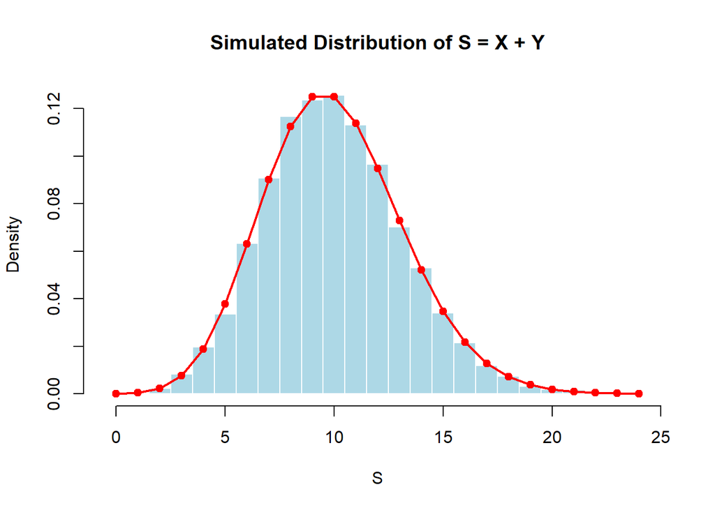

```r
hist(
  S,
  probability = TRUE,
  breaks = seq(-0.5, max(S) + 0.5, by = 1),
  main = "Simulated Distribution of S = X + Y",
  xlab = "S",
  col = "lightblue",
  border = "white"
)

points(
  0:max(S),
  dpois(0:max(S), lambda = 10),
  col = "red",
  pch = 19
)

lines(
  0:max(S),
  dpois(0:max(S), lambda = 10),
  col = "red",
  lwd = 2
)
```

## 2.6 Conclusion for Part 2

The sum of two independent Poisson random variables follows another Poisson distribution. The theoretical mean and variance are both equal to 10. The simulated values are expected to be close to the theoretical values because the simulation uses 10,000 observations.

# Part 3: Conditional Distributions – Discrete Case

## 3.1 Description of the Random Variables

This part uses two discrete random variables:

- X represents a student’s performance category: Low, Medium, or High.
- Y represents the type of study method: Method A or Method B.

The conditional probabilities are defined as follows:

| Performance | Method A | Method B |
| --- | --- | --- |
| Low | 0.60 | 0.20 |
| Medium | 0.30 | 0.30 |
| High | 0.10 | 0.50 |

Both study methods have an equal probability of being selected.

## 3.2 Generate Discrete Data

```r
n3 <- 10000

Y3 <- sample(
  c("Method A", "Method B"),
  size = n3,
  replace = TRUE,
  prob = c(0.5, 0.5)
)

X3 <- character(n3)

for (i in 1:n3) {
  if (Y3[i] == "Method A") {
    X3[i] <- sample(
      c("Low", "Medium", "High"),
      size = 1,
      prob = c(0.60, 0.30, 0.10)
    )
  } else {
    X3[i] <- sample(
      c("Low", "Medium", "High"),
      size = 1,
      prob = c(0.20, 0.30, 0.50)
    )
  }
}

X3 <- factor(X3, levels = c("Low", "Medium", "High"))
Y3 <- factor(Y3, levels = c("Method A", "Method B"))

head(data.frame(X3, Y3))
```

```
##       X3       Y3
## 1   High Method B
## 2 Medium Method A
## 3    Low Method A
## 4    Low Method A
## 5   High Method B
## 6 Medium Method B
```

## 3.3 Joint Probability Distribution

The joint distribution shows the probability of each combination of performance category and study method.

```r
joint_distribution <- prop.table(table(X3, Y3))

joint_distribution
```

```
##         Y3
## X3       Method A Method B
##   Low      0.3003   0.1007
##   Medium   0.1480   0.1565
##   High     0.0497   0.2448
```

## 3.4 Marginal Probability Distributions

The marginal distributions describe the probabilities of X and Y separately.

```r
marginal_X3 <- prop.table(table(X3))
marginal_Y3 <- prop.table(table(Y3))

marginal_X3
```

```
## X3
##    Low Medium   High
## 0.4010 0.3045 0.2945
```

```r
marginal_Y3
```

```
## Y3
## Method A Method B
##    0.498    0.502
```

## 3.5 Conditional Probability Distribution

The conditional distribution of X given Y is calculated by dividing the joint probabilities by the corresponding marginal probabilities of Y.

```r
conditional_distribution <- prop.table(
  table(X3, Y3),
  margin = 2
)

conditional_distribution
```

```
##         Y3
## X3        Method A  Method B
##   Low    0.6030120 0.2005976
##   Medium 0.2971888 0.3117530
##   High   0.0997992 0.4876494
```

The columns represent the conditional probabilities of each performance category given a particular study method.

## 3.6 Graphical Representation

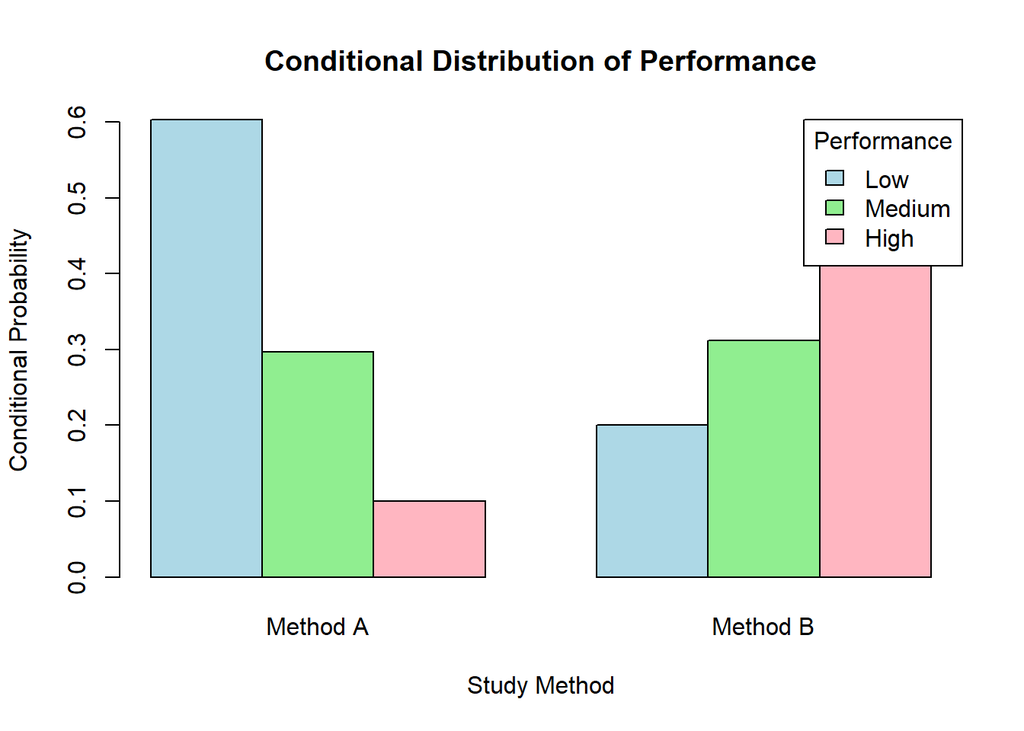

```r
barplot(
  conditional_distribution,
  beside = TRUE,
  col = c("lightblue", "lightgreen", "lightpink"),
  main = "Conditional Distribution of Performance",
  xlab = "Study Method",
  ylab = "Conditional Probability",
  legend.text = rownames(conditional_distribution),
  args.legend = list(
    title = "Performance",
    x = "topright"
  )
)
```

## 3.7 Interpretation

The conditional distribution shows that students using Method A have a higher probability of being in the Low performance category, while students using Method B have a higher probability of being in the High performance category.

This demonstrates that the distribution of performance depends on the study method.

## 3.8 Conclusion for Part 3

The joint and conditional distributions show that the performance category is associated with the study method. The probability of a student’s performance category changes depending on the method used.

# Part 4: Conditional Distributions – Continuous Case

## 4.1 Description of the Random Variables

Two continuous random variables are generated:

- X follows a standard normal distribution.
- Y is generated using X and an independent normal error term.

The relationship is defined as:

Y = 0.8X + error

The error term follows a normal distribution with mean 0 and standard deviation 0.6.

## 4.2 Generate Continuous Data

```r
n4 <- 10000

X4 <- rnorm(n4, mean = 0, sd = 1)
error <- rnorm(n4, mean = 0, sd = 0.6)

Y4 <- 0.8 * X4 + error

head(data.frame(X4, Y4))
```

```
##            X4         Y4
## 1 -0.02943448  0.1818890
## 2  0.23907703  0.1332921
## 3 -1.68805590 -0.7138290
## 4  0.52871291  0.8139197
## 5 -1.64622324 -1.3631732
## 6  2.49388656  2.3286079
```

## 4.3 Marginal Distributions

The marginal distributions of X and Y are examined separately.

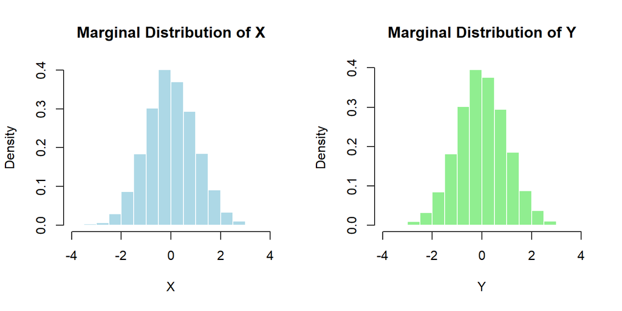

```r
par(mfrow = c(1, 2))

hist(
  X4,
  probability = TRUE,
  main = "Marginal Distribution of X",
  xlab = "X",
  col = "lightblue",
  border = "white"
)

hist(
  Y4,
  probability = TRUE,
  main = "Marginal Distribution of Y",
  xlab = "Y",
  col = "lightgreen",
  border = "white"
)
```

```r
par(mfrow = c(1, 1))
```

Both marginal distributions are approximately normal.

## 4.4 Joint Distribution

```r
smoothScatter(
  X4, Y4,
  main = "Joint Distribution of X and Y",
  xlab = "X",
  ylab = "Y"
)
```

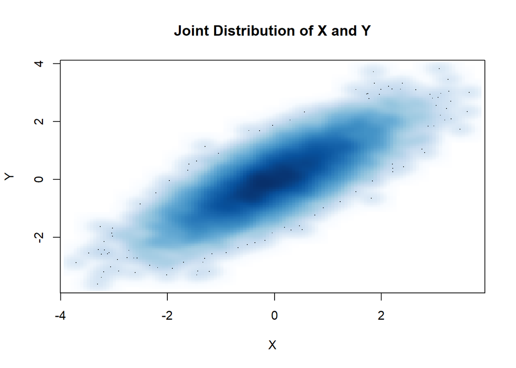

The joint distribution shows a positive relationship between X and Y.

## 4.5 Empirical Conditional Distribution

To examine the conditional distribution of X given Y, we select observations where Y falls between its 60th and 70th percentiles.

```r
lower_Y <- quantile(Y4, 0.60)
upper_Y <- quantile(Y4, 0.70)

conditional_X <- X4[
  Y4 >= lower_Y & Y4 <= upper_Y
]

cat("Lower limit of Y:", lower_Y, "\n")
```

```
## Lower limit of Y: 0.2466809
```

```r
cat("Upper limit of Y:", upper_Y, "\n")
```

```
## Upper limit of Y: 0.5283844
```

```r
cat("Number of selected observations:", length(conditional_X))
```

```
## Number of selected observations: 1000
```

## 4.6 Comparing the Distributions

The following graph compares the overall distribution of X with the empirical conditional distribution of X for the selected interval of Y.

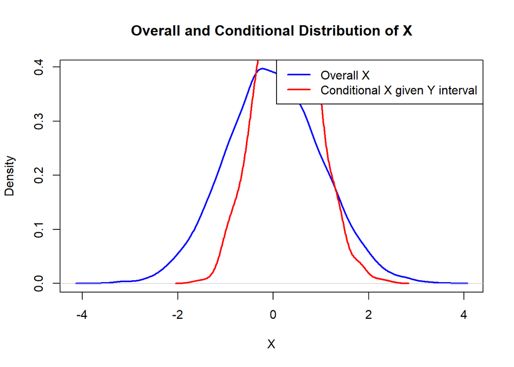

```r
plot(
  density(X4),
  main = "Overall and Conditional Distribution of X",
  xlab = "X",
  ylab = "Density",
  lwd = 2,
  col = "blue"
)

lines(
  density(conditional_X),
  col = "red",
  lwd = 2
)

legend(
  "topright",
  legend = c("Overall X", "Conditional X given Y interval"),
  col = c("blue", "red"),
  lwd = 2
)
```

## 4.7 Interpretation

The conditional distribution represents the distribution of X among observations where Y falls within the selected interval. It differs from the overall marginal distribution of X because X and Y are positively related.

The conditional density function is:

fX|Y(x|y) = fX,Y(x,y) / fY(y)

This means that the conditional density is obtained by dividing the joint density by the marginal density of Y, provided that the marginal density is positive.

## 4.8 Conclusion for Part 4

The simulation demonstrates how the conditional distribution of one continuous random variable can be studied by selecting observations within a specific interval of another variable. The conditional distribution differs from the overall marginal distribution because X and Y are related.

# Overall Conclusion

This assessment demonstrated important concepts in probability theory through simulation using R.

First, stochastic independence was examined through the relationship between two continuous random variables. The correlation and joint distribution showed that the variables were dependent.

Second, the sum of two independent Poisson random variables was investigated. The simulated mean and variance were compared with their theoretical values.

Third, conditional distributions for discrete random variables were calculated using joint and marginal probabilities. The results demonstrated how the probability of one variable changes depending on another variable.

Finally, conditional distributions for continuous random variables were explored through simulated data and density plots.

Overall, simulation provides a useful way to understand probability distributions, stochastic independence, and conditional relationships between random variables.